# Linear regression: Scottish hill races

Choosing predictors by cross-validation, reading residuals, and what “linear” actually constrains in a linear model.

The other vignettes are listed by `vignette (package = "fdm2id")`; they use the same handful of functions on other data, and can be read in any order.

```r
library (fdm2id)
```

# The data

Records of hill races in Scotland. Each race is described by three variables: its distance (in miles), its total climb (in feet), and the record time set in 1984 (in minutes). The question is whether the time can be predicted from the distance and the climb.

```r
data (hills, package = "MASS")
summary (hills)
```

```
#>       dist            climb           time
#>  Min.   : 2.000   Min.   : 300   Min.   : 15.95
#>  1st Qu.: 4.500   1st Qu.: 725   1st Qu.: 28.00
#>  Median : 6.000   Median :1000   Median : 39.75
#>  Mean   : 7.529   Mean   :1815   Mean   : 57.88
#>  3rd Qu.: 8.000   3rd Qu.:2200   3rd Qu.: 68.62
#>  Max.   :28.000   Max.   :7500   Max.   :204.62
```

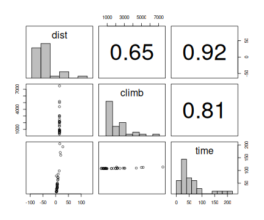

```r
plotdata (hills)
```

# Question 1. Which single variable predicts best? Was it foreseeable?

```r
# Reproducible without a seed: leave-one-out builds n folds of one observation each, so there
# is nothing to draw. It is the one protocol of the package that needs no 'seed'.
performance (LINREG, hills [, 1], hills [, 3], protocol = "loocv", eval = c ("adjr2", "msep"))
```

```
#>       adjr2        msep
#>   0.7835907 510.9387160
```

```r
performance (LINREG, hills [, 2], hills [, 3], protocol = "loocv", eval = c ("adjr2", "msep"))
```

```
#>       adjr2        msep
#>   0.6035177 936.0880207
```

**Answer.** *Under leave-one-out cross-validation, `dist` predicts more precisely than `climb`. It was foreseeable: its linear correlation with `time` is the higher of the two.*

```r
round (cor (hills), 3)
```

```
#>        dist climb  time
#> dist  1.000 0.652 0.920
#> climb 0.652 1.000 0.805
#> time  0.920 0.805 1.000
```

# Question 2. One variable or two?

```r
performance (LINREG, hills [, -3], hills [, 3], protocol = "loocv", eval = c ("adjr2", "msep"))
```

```
#>       adjr2        msep
#>   0.8774988 280.4588630
```

**Answer.** *Two. The mean squared error of prediction drops by nearly half.*

# Question 3. What do the residuals say?

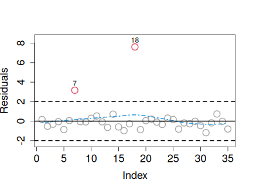

```r
model = LINREG (hills [, -3], hills [, 3])
resplot (model)
```

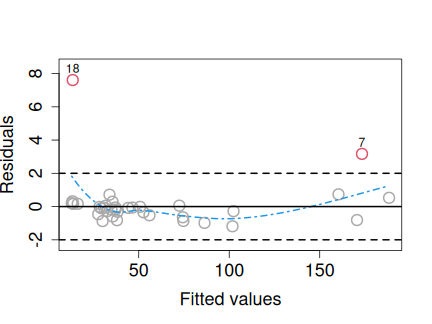

```r
resplot (model, index = "fitted")
```

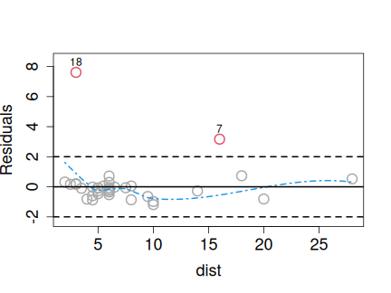

```r
resplot (model, index = 1)
```

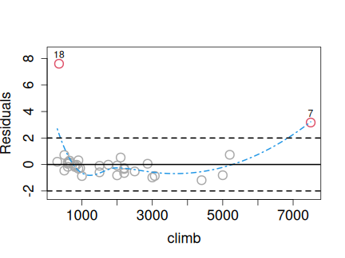

```r
resplot (model, index = 2)
```

**Answer.** *Two races stand out: one of the flattest, and the steepest of them all.*

```r
head (sort (abs (residuals (model)), decreasing = TRUE), 3)
```

```
#>   Knock Hill Bens of Jura    Ben Nevis
#>     65.12140     31.26242     16.21532
```

```r
hills [c ("Knock Hill", "Bens of Jura"), ]
```

```
#>              dist climb    time
#> Knock Hill      3   350  78.650
#> Bens of Jura   16  7500 204.617
```

# Question 4. Can the predictions be improved?

The residuals plotted against `climb` are vaguely parabolic, which suggests adding a `climb²` variable:

```r
hills2 = cbind (hills, hills$climb^2)
colnames (hills2) = c (colnames (hills), "climb2")
performance (LINREG, hills2 [, -3], hills2 [, 3], protocol = "loocv",
             eval = c ("adjr2", "msep"))
```

```
#>       adjr2        msep
#>   0.9263591 163.3276285
```

**Answer.** *Under leave-one-out cross-validation this improves the predictions markedly – the error falls again by more than a third. A linear model is linear in its coefficients, not in the variables it is given.*